# Examen final de Introducción a R - Versión B

- Mostrar todo el código
- Ocultar todo el código
- Ver el código fuente

Bioinformática I — Versión B

Autor/a

Fernanda Ximena Venegas García

## Instrucciones generales

**Duración: 120 minutos. Valor total: 100 puntos.**

El objetivo es reproducir dos figuras a partir de datos reales de mieles de abejas sin aguijón. Los conteos proporcionados corresponden únicamente a bacterias con asignación taxonómica a nivel de filo. Se incluyen 17 muestras de dos especies de abejas.

Trabaja en tu proyecto de RStudio y utiliza este documento como [plantilla](https://github.com/CursosENESJuriquilla/Intro_to_R_Bioinfo_2027-1/raw/refs/heads/main/versionB.qmd) Sustituye el nombre del autor por el tuyo. Agrega tus bloques de código R ejecutables y tus respuestas en las secciones correspondientes. Conserva las rutas relativas y muestra el procedimiento completo. Las figuras de referencia son una guía: no es necesario reproducir exactamente la tipografía ni los tamaños.

## Importación y exploración (10 puntos)

Descarga y descomprime datos_B.zip. Importa con `readr` los archivos `datos/conteos_filo_miel_bacterias.tsv` y `datos/metadata_miel_examen.csv`.

- Indica las dimensiones de ambas tablas y el número de muestras por especie de abeja.
  - Conteos filo tiene 867 filas, 3 columnas. Metadata miel tiene 17 filas, 14 columnas.
  - Melipona beecheii 9, Scaptrotrigona mexicana 8.
- Identifica si existen valores faltantes en los metadatos e indica en qué variable o variables.
  - Si, en Total_sugar y son 2 los valores faltantes.

Importación de los archivos:

**Código**

```r
library(readr)

conteos_filo <- read_tsv("datos_B/conteos_filo_miel_bacterias.tsv")
metadata_miel <- read_csv("datos_B/metadata_miel_examen.csv")
```

Para ver el formato de las tablas:

**Código**

```r
names(conteos_filo)
```

```
[1] "sample_id" "filo"      "conteo"
```

**Código**

```r
head(conteos_filo, 5)
```

```
# A tibble: 5 × 3
  sample_id filo            conteo
  <chr>     <chr>            <dbl>
1 Melli_21  Acidobacteriota   2179
2 Melli_21  Actinomycetota   74632
3 Melli_21  Aquificota         324
4 Melli_21  Armatimonadota     238
5 Melli_21  Atribacterota       19
```

**Código**

```r
names(metadata_miel)
```

```
 [1] "sample_id"            "species"              "State"
 [4] "City"                 "Region"               "Zootechnic_mangement"
 [7] "Flowering_type"       "Moisture"             "HMF"
[10] "Color"                "pH"                   "Conductivity"
[13] "Ash"                  "Total_sugar"
```

**Código**

```r
head(metadata_miel)
```

```
# A tibble: 6 × 14
  sample_id species       State City  Region Zootechnic_mangement Flowering_type
  <chr>     <chr>         <chr> <chr> <chr>  <chr>                <chr>
1 Melli_21  Melipona bee… QR    Jose… Sures… Mixed honey          Multifloral
2 Melli_22  Melipona bee… QR    Jose… Sures… Jobon                Multifloral
3 Melli_39  Melipona bee… QR    Jose… Sures… Beehive box          Multifloral
4 Melli_40  Melipona bee… QR    Jose… Sures… Beehive box          Multifloral
5 Melli_41  Melipona bee… QR    Jose… Sures… Mixed honey          Multifloral
6 Melli_42  Melipona bee… QR    Jose… Sures… Jobon                Multifloral
# ℹ 7 more variables: Moisture <dbl>, HMF <dbl>, Color <chr>, pH <dbl>,
#   Conductivity <dbl>, Ash <dbl>, Total_sugar <dbl>
```

Dimensión de las tablas (aunque esta información ya aparece en el código anterior, solo es otra forma de obtenerlo):

**Código**

```r
library(dplyr)

# Filas y columnas
dim(conteos_filo)
```

```
[1] 867   3
```

**Código**

```r
dim(metadata_miel)
```

```
[1] 17 14
```

Número de muestras por especie de abeja:

**Código**

```r
names(metadata_miel)
```

```
 [1] "sample_id"            "species"              "State"
 [4] "City"                 "Region"               "Zootechnic_mangement"
 [7] "Flowering_type"       "Moisture"             "HMF"
[10] "Color"                "pH"                   "Conductivity"
[13] "Ash"                  "Total_sugar"
```

**Código**

```r
metadata_miel %>%
  count(species, name = "n_muestras")
```

```
# A tibble: 2 × 2
  species                n_muestras
  <chr>                       <int>
1 Melipona beecheii               9
2 Scaptotrigona mexicana          8
```

Identificación de valores faltantes:

**Código**

```r
# Conteo de NA por columna y sus variables
na_cols <- colSums(is.na(metadata_miel))
na_cols[na_cols > 0]
```

```
Total_sugar
          2
```

## Integración y abundancia relativa (20 puntos)

Integra las dos tablas mediante el identificador `sample_id`. Calcula la abundancia relativa de cada filo dentro de cada muestra, dividiendo su conteo entre la suma de los conteos de esa muestra. Conserva las abundancias como proporciones entre 0 y 1.

**Código**

```r
tablas_integradas <- conteos_filo %>%
  group_by(sample_id) %>%
  mutate(total_muestra = sum(conteo, na.rm = TRUE),
    abundancia = conteo / total_muestra) %>%
  ungroup() %>%
  inner_join(metadata_miel, by = "sample_id")

# Para verificr que se hizo correctamente
glimpse(tablas_integradas)
```

```
Rows: 867
Columns: 18
$ sample_id            <chr> "Melli_21", "Melli_21", "Melli_21", "Melli_21", "…
$ filo                 <chr> "Acidobacteriota", "Actinomycetota", "Aquificota"…
$ conteo               <dbl> 2179, 74632, 324, 238, 19, 5957594, 68835, 117, 2…
$ total_muestra        <dbl> 6471053, 6471053, 6471053, 6471053, 6471053, 6471…
$ abundancia           <dbl> 3.367304e-04, 1.153321e-02, 5.006913e-05, 3.67791…
$ species              <chr> "Melipona beecheii", "Melipona beecheii", "Melipo…
$ State                <chr> "QR", "QR", "QR", "QR", "QR", "QR", "QR", "QR", "…
$ City                 <chr> "Jose Maria Morelos", "Jose Maria Morelos", "Jose…
$ Region               <chr> "Sureste", "Sureste", "Sureste", "Sureste", "Sure…
$ Zootechnic_mangement <chr> "Mixed honey", "Mixed honey", "Mixed honey", "Mix…
$ Flowering_type       <chr> "Multifloral", "Multifloral", "Multifloral", "Mul…
$ Moisture             <dbl> 21.9, 21.9, 21.9, 21.9, 21.9, 21.9, 21.9, 21.9, 2…
$ HMF                  <dbl> 1.6, 1.6, 1.6, 1.6, 1.6, 1.6, 1.6, 1.6, 1.6, 1.6,…
$ Color                <chr> "Light Amber", "Light Amber", "Light Amber", "Lig…
$ pH                   <dbl> 6.175, 6.175, 6.175, 6.175, 6.175, 6.175, 6.175, …
$ Conductivity         <dbl> 366, 366, 366, 366, 366, 366, 366, 366, 366, 366,…
$ Ash                  <dbl> 0.13, 0.13, 0.13, 0.13, 0.13, 0.13, 0.13, 0.13, 0…
$ Total_sugar          <dbl> 468, 468, 468, 468, 468, 468, 468, 468, 468, 468,…
```

**Código**

```r
range(tablas_integradas$abundancia)
```

```
[1] 0.0000000 0.9206529
```

## Figura 1: los 10 filos más abundantes (25 puntos)

Calcula la abundancia relativa promedio de cada filo considerando las 17 muestras, incluidos los conteos cero. Selecciona los diez con mayor promedio y reproduce la gráfica de barras horizontales ordenadas de mayor a menor. Muestra el eje de abundancia en porcentajes y agrega etiquetas apropiadas.

[figure not shown]

Figura 1. Referencia.

**Código**

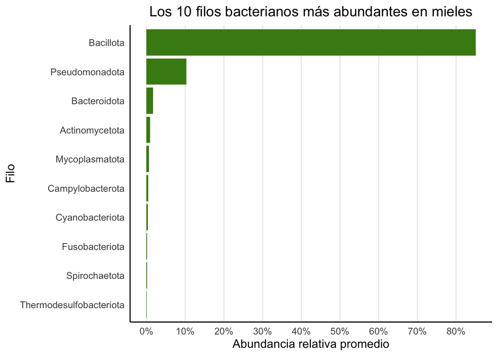

```r
library(tidyr)
library(ggplot2)
library(scales)

mejores_filos <- tablas_integradas %>%
  complete(sample_id, filo, fill = list(abundancia = 0)) %>%
  group_by(filo) %>%
  summarise(abundancia_promedio = mean(abundancia), .groups = "drop") %>%
  slice_max(order_by = abundancia_promedio, n = 10)

# Gráfica de barras
filos_best <- ggplot(mejores_filos,
                  aes(x = abundancia_promedio, y = reorder(filo, abundancia_promedio))) +
  geom_col(fill = "#468915") +
  scale_x_continuous(
    breaks = seq(0, 0.8, by = 0.1),
    labels = function(x) paste0(round(100 * x), "%")
  ) +
  labs(
    title = "Los 10 filos bacterianos más abundantes en mieles",
    x = "Abundancia relativa promedio",
    y = "Filo"
  ) +
  theme_minimal(base_size = 12) +
  theme(
    plot.title = element_text(hjust = 0.5),
    panel.grid.major.y = element_blank(),
    panel.grid.minor = element_blank(),
    axis.line = element_line(color = "black")
  )

filos_best
```

## Figura 2: composición bacteriana por muestra (30 puntos)

Utiliza las abundancias relativas del apartado 2, **no solamente los diez taxones de la figura anterior**.

- Dentro de cada muestra, agrupa los filos cuya abundancia relativa sea estrictamente menor al 5 % en la categoría `Filos < 5%`. Suma las abundancias de esa categoría.
- Construye una gráfica de barras apiladas, una barra por muestra, separando las especies de abejas mediante facetas. Cada barra debe sumar 100 %.
- Utiliza la paleta proporcionada y coloca la leyenda debajo de la gráfica.

Paleta de referencia (puedes copiarla en un bloque de R) o puedes usar otra paleta de colores:

```r
phylum_colors_rel <- c(
  "Bacillota" = "#0078A0",
  "Pseudomonadota" = "#499878",
  "Filos < 5%" = "#778899"
)
```

[figure not shown]

Figura 2. Referencia.

**Código**

```r
# Agrupar filos < 5 % dentro de cada muestra, suma de sus abundancias
filos_agrupados <- tablas_integradas %>%
  mutate(
    taxon_final = if_else(abundancia < 0.05, "Filos < 5%", filo)
  ) %>%
  group_by(sample_id, species, taxon_final) %>%
  summarise(
    abundancia_relativa = sum(abundancia, na.rm = TRUE),
    .groups = "drop"
  )

# Cada muestra suma 100%
filos_agrupados %>%
  group_by(sample_id) %>%
  summarise(suma = sum(abundancia_relativa))
```

```
# A tibble: 17 × 2
   sample_id  suma
   <chr>     <dbl>
 1 Melli_21      1
 2 Melli_22      1
 3 Melli_39      1
 4 Melli_40      1
 5 Melli_41      1
 6 Melli_42      1
 7 Melli_45      1
 8 Melli_46      1
 9 Melli_47      1
10 Scapto_23     1
11 Scapto_43     1
12 Scapto_51     1
13 Scapto_89     1
14 Scapto_90     1
15 Scapto_91     1
16 Scapto_92     1
17 Scapto_93     1
```

**Código**

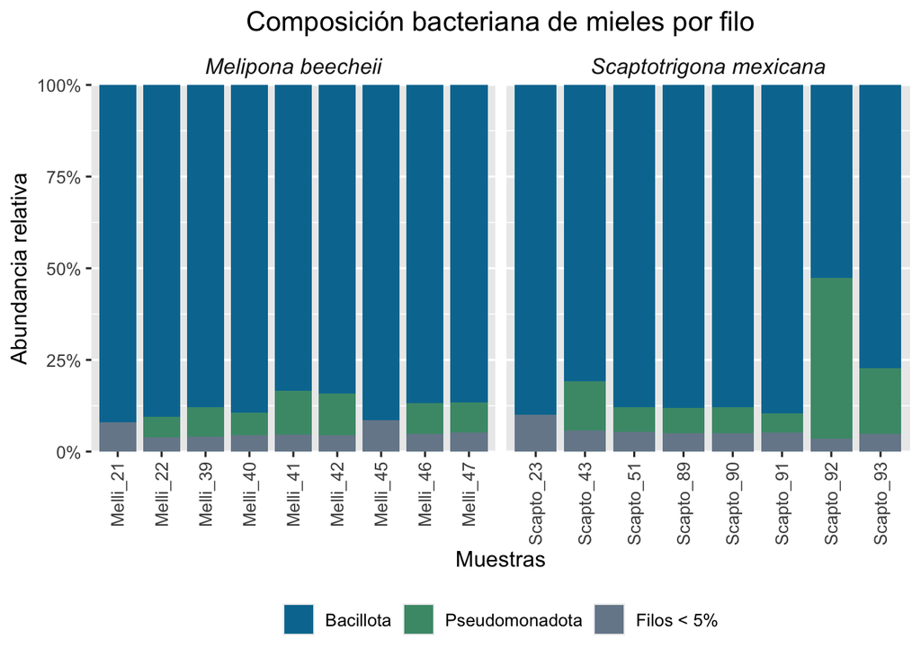

```r
# Gráfica
orden_filos <- c("Bacillota", "Pseudomonadota", "Filos < 5%")

phylum_colors_rel <- c(
  "Bacillota" = "#0078A0",
  "Pseudomonadota" = "#499878",
  "Filos < 5%" = "#778899"
)

filos_agrupados <- filos_agrupados %>%
  mutate(taxon_final = factor(taxon_final, levels = orden_filos))

p_composicion <- ggplot(
  filos_agrupados,
  aes(x = sample_id, y = abundancia_relativa, fill = taxon_final)
) +
  geom_col(width = 0.85) +
  facet_wrap(~ species, scales = "free_x") +
  scale_fill_manual(values = phylum_colors_rel, breaks = orden_filos) +
  scale_y_continuous(
    labels = function(x) paste0(round(100 * x), "%"),
    expand = c(0, 0)
  ) +
  labs(
    title = "Composición bacteriana de mieles por filo",
    x = "Muestras",
    y = "Abundancia relativa",
    fill = NULL
  ) +
  theme_gray(base_size = 12) +
  theme(
    plot.title = element_text(hjust = 0.5, size = 15),
    strip.background = element_blank(),
    strip.text = element_text(face = "italic", size = 12),
    axis.text.x = element_text(angle = 90, vjust = 0.5, hjust = 1),
    legend.position = "bottom"
  )

p_composicion
```

## Interpretación (5 puntos)

Responde brevemente con base en tus resultados:

1. ¿Cuál es el filo con mayor abundancia relativa promedio? Bacillota es la de mayor abundancia relativa promedio.
2. ¿Qué diferencias o similitudes observas en la composición de las muestras de las dos especies de abejas? Hay una diferencia de 1 muestra entre las dos especies observadas (Melipona beechii con 9 y Scaptotrigona mexicana 8), para ambas especies Bacillota es el filo más abundante, seguido de psudomonadota.

**Nota**: Todas las muestras pertenecen al mismo estudio y fueron procesadas con la misma metodología.

## Reporte reproducible y entrega (10 puntos)

Renderiza el documento a HTML y sube a tu repositorio de GitHub el archivo `.qmd`, el HTML generado y las carpetas de datos y figuras necesarias. Verifica que el HTML muestre tus resultados y gráficas sin necesidad de ejecutar el código nuevamente. Entrega el enlace al repositorio.

Si tienes un problema técnico con GitHub, conserva el `.qmd` y el HTML y notifícalo a la profesora antes de finalizar el examen.